# ACR Remote Sensing Validation Plot Demo

Synthetic PNW forest tract, n = 45 validation plots

Author

TÜV SÜD America - Forestry Team

Published

April 14, 2026

## Background

The American Carbon Registry’s *Methodology Framework for Remotely Sensed Quantification of Forest Carbon* ([v1.0, 2026](https://acrcarbon.org/program_resources/framework-for-remotely-sensed-quantification-of-forest-carbon/)) relies on ground-truth validation plots to calibrate and verify remotely sensed biomass estimates. ACR’s supporting [R script](https://acrcarbon.org/wp-content/uploads/2026/03/ACR-Script-for-Validation-Plot-Location-Generation.r) (`ACR-Script-for-Validation-Plot-Location-Generation.r`) draws N random plot centers uniformly inside a project polygon, using an equal-area projection (EPSG:6933) to avoid latitude bias when the input is in geographic coordinates.

This notebook stands up a reproducible demonstration. No real project data are used. The AOI is a synthetic ~5,000 ha forest tract in the Oregon Cascades; n = 45 plots (the ACR minimum); seed = `20260414`.

## Setup

```r
library(sf)
library(ggplot2)
library(dplyr)
library(readr)
library(leaflet)
library(htmlwidgets)
library(knitr)

set.seed(20260414)

output_dir <- "outputs"
if (!dir.exists(output_dir)) dir.create(output_dir, recursive = TRUE)
```

## Synthetic AOI

We derived an irregular, non-convex polygon from a radius with some random edge noise, centered near 44.5°N, 122.5°W (Willamette National Forest). The polygon is written to both KMZ and SHP for purpose of testing the full ACR script.

```r
centroid_lon <- -122.5
centroid_lat <-   44.5
target_ha    <- 5000

# Approximate radius in degrees for ~5,000 ha at this latitude
# 1 deg lat ~ 111 km; 1 deg lon ~ 111 km * cos(lat)
km_per_deg_lat <- 111
km_per_deg_lon <- 111 * cos(centroid_lat * pi / 180)
target_radius_km <- sqrt(target_ha / 100 / pi)  # ha -> km^2 -> km radius

n_vert <- 120
theta  <- seq(0, 2 * pi, length.out = n_vert + 1)[-1]
radius_km <- target_radius_km *
  (1 + 0.25 * sin(3 * theta) + 0.12 * cos(5 * theta) +
       runif(n_vert, -0.06, 0.06))

lon <- centroid_lon + (radius_km * cos(theta)) / km_per_deg_lon
lat <- centroid_lat + (radius_km * sin(theta)) / km_per_deg_lat
coords <- rbind(cbind(lon, lat), c(lon[1], lat[1]))

poly_sfc <- st_sfc(st_polygon(list(coords)), crs = 4326)
aoi <- st_sf(name = "Demo AOI", geometry = poly_sfc) |> st_make_valid()

aoi_area_ha <- as.numeric(st_area(st_transform(aoi, 6933))) / 1e4
cat(sprintf("AOI area: %.0f ha\n", aoi_area_ha))
```

```
AOI area: 5230 ha
```

```r
print(st_bbox(aoi))
```

```
      xmin       ymin       xmax       ymax
-122.56117   44.45228 -122.43899   44.53493
```

```r
# Write SHP
shp_aoi <- file.path("aoi.shp")
suppressWarnings(st_write(aoi, shp_aoi, delete_layer = TRUE, quiet = TRUE))

# Write KMZ (zip a KML)
kml_tmp <- tempfile(fileext = ".kml")
st_write(aoi, kml_tmp, delete_dsn = TRUE, quiet = TRUE)
kmz_aoi <- "aoi.kmz"
zip(kmz_aoi, files = kml_tmp, flags = "-j9X")
```

## Generate validation plot centers

The following block mirrors the published ACR script: read the polygon, transform to EPSG:6933 for equal-area sampling, draw `n_points = 45` random points with `sf::st_sample()`, re-project, and export CSV / SHP / KML.

```r
n_points <- 45
input_path <- kmz_aoi

read_polygon <- function(path) {
  ext <- tolower(tools::file_ext(path))
  if (ext == "shp") return(st_read(path, quiet = TRUE))
  if (ext == "kmz") {
    tmpdir <- tempfile("kmz_unzip_"); dir.create(tmpdir)
    unzip(path, exdir = tmpdir)
    kml_files <- list.files(tmpdir, pattern = "\\.kml$",
                            full.names = TRUE, recursive = TRUE)
    if (length(kml_files) == 0) stop("No .kml found inside the KMZ.")
    return(st_read(kml_files[1], quiet = TRUE))
  }
  stop("Unsupported file type.")
}

poly <- read_polygon(input_path) |> st_make_valid()
poly <- poly |>
  filter(st_geometry_type(geometry) %in% c("POLYGON", "MULTIPOLYGON"))
if (nrow(poly) > 1) {
  poly <- st_union(poly) |> st_as_sf()
  names(poly)[names(poly) == "x"] <- "geometry"
}

poly_sampling <- if (st_is_longlat(poly)) st_transform(poly, 6933) else poly

pts_geom <- st_sample(poly_sampling, size = n_points,
                      type = "random", exact = TRUE)
pts_sf <- st_as_sf(pts_geom) |>
  mutate(PointID = sprintf("P%02d", dplyr::row_number()))
pts_out <- st_transform(pts_sf, st_crs(poly))

xy_native <- st_coordinates(pts_out)
pts_ll    <- st_transform(pts_out, 4326)
xy_ll     <- st_coordinates(pts_ll)

pts_table <- tibble(
  PointID = pts_out$PointID,
  Lon = xy_ll[,1], Lat = xy_ll[,2],
  X = xy_native[,1], Y = xy_native[,2]
)

csv_path <- file.path(output_dir, "random_points_45.csv")
shp_path <- file.path(output_dir, "random_points_45.shp")
kml_path <- file.path(output_dir, "random_points_45.kml")
png_path <- file.path(output_dir, "random_points_45_map.png")
html_path<- file.path(output_dir, "random_points_45_map.html")

write_csv(pts_table, csv_path)
suppressWarnings(st_write(pts_out, shp_path, delete_layer = TRUE, quiet = TRUE))
st_write(st_transform(pts_out, 4326), kml_path,
         delete_dsn = TRUE, quiet = TRUE)
```

## Static map

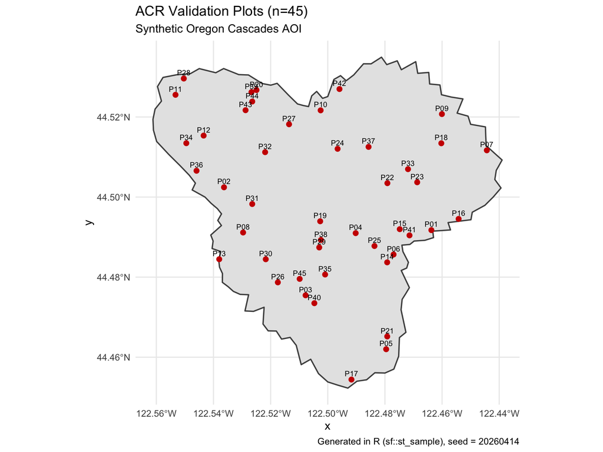

```r
p <- ggplot() +
  geom_sf(data = poly, fill = "grey90", color = "grey30", linewidth = 0.6) +
  geom_sf(data = pts_out, color = "red3", size = 2) +
  geom_sf_text(data = pts_out, aes(label = PointID),
               size = 2.5, nudge_y = 0.0015) +
  labs(
    title = paste0("ACR Validation Plots (n=", n_points, ")"),
    subtitle = "Synthetic Oregon Cascades AOI",
    caption = "Generated in R (sf::st_sample), seed = 20260414"
  ) +
  theme_minimal()

ggsave(png_path, p, width = 8, height = 6, dpi = 300)
p
```

## Interactive leaflet map

```r
leaf <- leaflet() |>
  addProviderTiles(providers$Esri.WorldImagery, group = "Imagery") |>
  addProviderTiles(providers$CartoDB.Positron, group = "Basemap") |>
  addPolygons(
    data = st_transform(poly, 4326),
    fillColor = "#cccccc", fillOpacity = 0.25,
    color = "#444444", weight = 2, group = "AOI"
  ) |>
  addCircleMarkers(
    data = st_transform(pts_out, 4326),
    radius = 5, color = "red", fillOpacity = 0.9,
    label = ~PointID, popup = ~paste0("<b>", PointID, "</b>"),
    group = "Validation plots"
  ) |>
  addLayersControl(
    baseGroups = c("Basemap", "Imagery"),
    overlayGroups = c("AOI", "Validation plots"),
    options = layersControlOptions(collapsed = FALSE)
  )

saveWidget(leaf, file = normalizePath(html_path, mustWork = FALSE),
           selfcontained = TRUE)
leaf
```

[interactive chart not shown]

## First 10 plot coordinates

```r
kable(head(pts_table, 10), digits = 5,
      caption = "Preview of random_points_45.csv")
```

Preview of random_points_45.csv

| PointID | Lon | Lat | X | Y |
| --- | --- | --- | --- | --- |
| P01 | -122.4638 | 44.49174 | -122.4638 | 44.49174 |
| P02 | -122.5363 | 44.50244 | -122.5363 | 44.50244 |
| P03 | -122.5078 | 44.47546 | -122.5078 | 44.47546 |
| P04 | -122.4902 | 44.49099 | -122.4902 | 44.49099 |
| P05 | -122.4796 | 44.46199 | -122.4796 | 44.46199 |
| P06 | -122.4770 | 44.48565 | -122.4770 | 44.48565 |
| P07 | -122.4443 | 44.51168 | -122.4443 | 44.51168 |
| P08 | -122.5296 | 44.49114 | -122.5296 | 44.49114 |
| P09 | -122.4600 | 44.52073 | -122.4600 | 44.52073 |
| P10 | -122.5025 | 44.52166 | -122.5025 | 44.52166 |

## Outputs

The interactive map is also embedded directly in this rendered HTML document.